# Lab 2 - Tutorial

Nicholas Nagle

February 2, 2015

In the data folder there are two files:

- rwi.csv: a tree ring chronology from El Malpais National Monument. The chronology measures for each year how much the trees tended to grow larger or small than average. A value of 1 means that the tree rings are an expected width. Values greater than one mean wider than expected tree, and values less than one means narrower than expected trees.
- precip.csv: a file with monthly precipitation totals for the area.

First, let’s do some preliminary work: setting the workspace, loading libraries and loading data.

```r
setwd('~/Dropbox/git_root/homework/homework2/')
```

```r
library(ggplot2)
library(dplyr)
library(tidyr)
library(magrittr) # for the %$% notation I'll use later.
```

```r
precip <- read.csv('data/precip.csv')
rwi <- read.csv('data/rwi.csv')

summary(rwi)
```

```
##       year           rwi           samp.depth
##  Min.   :-136   Min.   :-0.033   Min.   : 1.0
##  1st Qu.: 399   1st Qu.: 0.661   1st Qu.: 8.0
##  Median : 934   Median : 0.966   Median :13.0
##  Mean   : 934   Mean   : 0.977   Mean   :16.4
##  3rd Qu.:1469   3rd Qu.: 1.259   3rd Qu.:23.0
##  Max.   :2004   Max.   : 3.064   Max.   :66.0
```

```r
summary(precip)
```

```
##       year           Jan             Feb             Mar
##  Min.   :1895   Min.   :0.020   Min.   :0.030   Min.   :0.020
##  1st Qu.:1925   1st Qu.:0.335   1st Qu.:0.350   1st Qu.:0.448
##  Median :1954   Median :0.710   Median :0.680   Median :0.695
##  Mean   :1954   Mean   :0.837   Mean   :0.834   Mean   :0.864
##  3rd Qu.:1984   3rd Qu.:1.198   3rd Qu.:1.157   3rd Qu.:1.242
##  Max.   :2014   Max.   :2.790   Max.   :3.310   Max.   :3.180
##       Apr             May             Jun             Jul
##  Min.   :0.010   Min.   :0.000   Min.   :0.000   Min.   :0.86
##  1st Qu.:0.228   1st Qu.:0.150   1st Qu.:0.245   1st Qu.:1.88
##  Median :0.500   Median :0.360   Median :0.605   Median :2.56
##  Mean   :0.653   Mean   :0.544   Mean   :0.713   Mean   :2.66
##  3rd Qu.:0.873   3rd Qu.:0.802   3rd Qu.:1.093   3rd Qu.:3.29
##  Max.   :2.980   Max.   :3.010   Max.   :2.500   Max.   :5.96
##       Aug            Sep            Oct             Nov
##  Min.   :0.60   Min.   :0.03   Min.   :0.000   Min.   :0.000
##  1st Qu.:2.25   1st Qu.:1.06   1st Qu.:0.388   1st Qu.:0.205
##  Median :2.81   Median :1.77   Median :0.890   Median :0.590
##  Mean   :2.86   Mean   :1.82   Mean   :1.147   Mean   :0.725
##  3rd Qu.:3.39   3rd Qu.:2.43   3rd Qu.:1.653   3rd Qu.:0.970
##  Max.   :5.82   Max.   :5.11   Max.   :5.180   Max.   :4.030
##       Dec
##  Min.   :-9.990
##  1st Qu.: 0.368
##  Median : 0.780
##  Mean   : 0.916
##  3rd Qu.: 1.460
##  Max.   : 3.920
```

Note that the ring width data starts in Year -136 BCE and ends in 2004. The rainfall data is monthly, beginning in 1895 and ending whenever I pulled the data from the NOAA website (so you can get more recent data now).

# Initial Plotting

As usual, let’s see what the data look like:

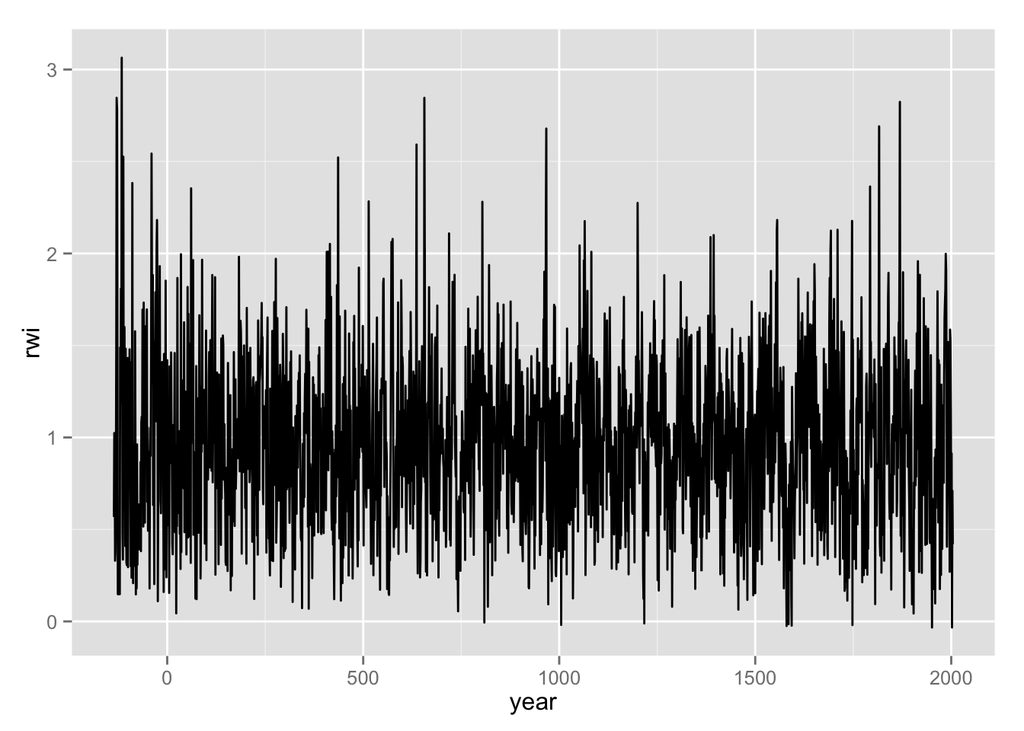

```r
ggplot(data=rwi) + geom_line(aes(x=year, y=rwi))
```

That’s a lot of data. You might want to subset to the last century or so (when we have precipiation data). I’ll show a few ways of doing this. I commented out the first one.

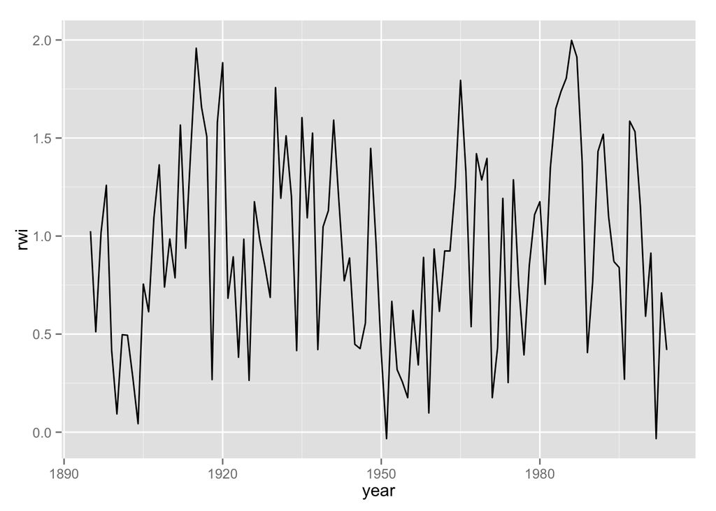

```r
# Using the subset function and temporary data:
# temp.data <- subset(rwi, year>=1895)
# ggplot(data=temp.data + geom_line(aes(x=year, y=rwi))
#
# It's possible to combine those two:
# ggplot(data= subset(rwi, year>1895)) + geom_line(aes(x=year, y=rwi))


# Using the really awesome dplyr function and its filter function
filter(rwi, year >= 1895) %>% ggplot(data=.) + geom_line(aes(x=year, y=rwi))
```

The dplyr package allows you to manipulate your data and “chain” together commands in a really intuitive way. In the above command, I used `filter` to create a new dataset with only years from 1895 and later, and then fed that data into ggplot using the `%>%`. The ‘.’ is where the new data set gets used. A lot of people really like using the dplyr package.

Now plot the August rainfall data:

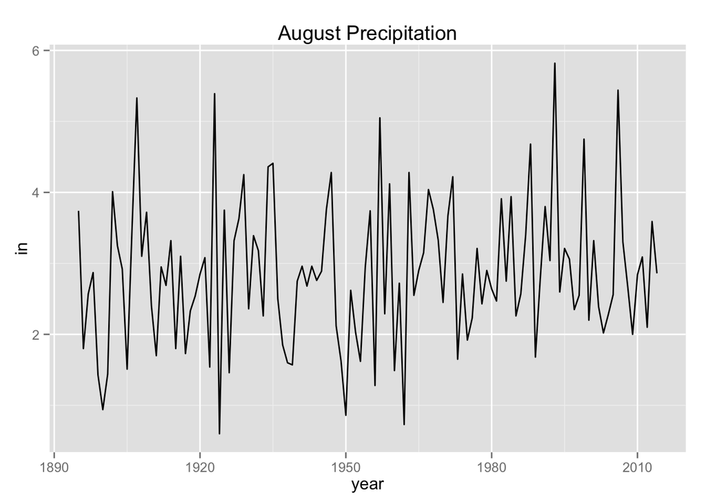

```r
ggplot(data=precip) + geom_line(aes(x=year,y=Aug)) + labs(y="in", title="August Precipitation")
```

You could obviously do the same thing for other months.

# Some plots requiring a little more advanced data manipulation

I want to create two plots: one in which each precipitation is plotted for every single year/month observation, and another in which we plot the monthly average for each month. In order to do these, we will first create what is called “tidy” data, data in which each row represent one row. (If you’re good at MS Excel, you would know this a “pivot table” type of operation)

```r
temp.data <- gather(data=precip, key=month, value=precip, -year)
head(temp.data) # They're not in order
```

```
##   year month precip
## 1 1895   Jan   1.08
## 2 1896   Jan   0.25
## 3 1897   Jan   1.29
## 4 1898   Jan   1.13
## 5 1899   Jan   0.22
## 6 1900   Jan   0.69
```

```r
# Rearrange them
tidy.precip <- arrange(temp.data, year, month)
head(tidy.precip) # Now they're in order
```

```
##   year month precip
## 1 1895   Jan   1.08
## 2 1895   Feb   0.78
## 3 1895   Mar   0.11
## 4 1895   Apr   0.10
## 5 1895   May   1.12
## 6 1895   Jun   0.63
```

The `gather` command gathered together every single column except year. Before, we had the precipitation data spread across 12 columns, now all of the precipitation dataare gathered into one column, and we’ve added a new column that has the month name. When it gathers, it creates a new column called `month` that has the variable name (or `key`), and a new column precip that has the data value.

Now I want to plot the precipitation data for every observation. In order to do this, we need to create a new column that is a “date”. Dates are specially formatted. They’re not numbers and they’re not text. They’re somthing different. When things are stored as dates, then the software can order or filter them based on the date.

```r
# Create a new column that is a date text string (but still a string)
# In dplyr, mutate is the function to create a new column.
# and paste is the function to paste together text
temp.data <- mutate(tidy.precip, date.str = paste(year, month, '01'))
head(temp.data)
```

```
##   year month precip    date.str
## 1 1895   Jan   1.08 1895 Jan 01
## 2 1895   Feb   0.78 1895 Feb 01
## 3 1895   Mar   0.11 1895 Mar 01
## 4 1895   Apr   0.10 1895 Apr 01
## 5 1895   May   1.12 1895 May 01
## 6 1895   Jun   0.63 1895 Jun 01
```

```r
# Convert that text string to a proper date
temp.data <- mutate(temp.data, date=as.Date(date.str, '%Y %B %d'))
head(temp.data)
```

```
##   year month precip    date.str       date
## 1 1895   Jan   1.08 1895 Jan 01 1895-01-01
## 2 1895   Feb   0.78 1895 Feb 01 1895-02-01
## 3 1895   Mar   0.11 1895 Mar 01 1895-03-01
## 4 1895   Apr   0.10 1895 Apr 01 1895-04-01
## 5 1895   May   1.12 1895 May 01 1895-05-01
## 6 1895   Jun   0.63 1895 Jun 01 1895-06-01
```

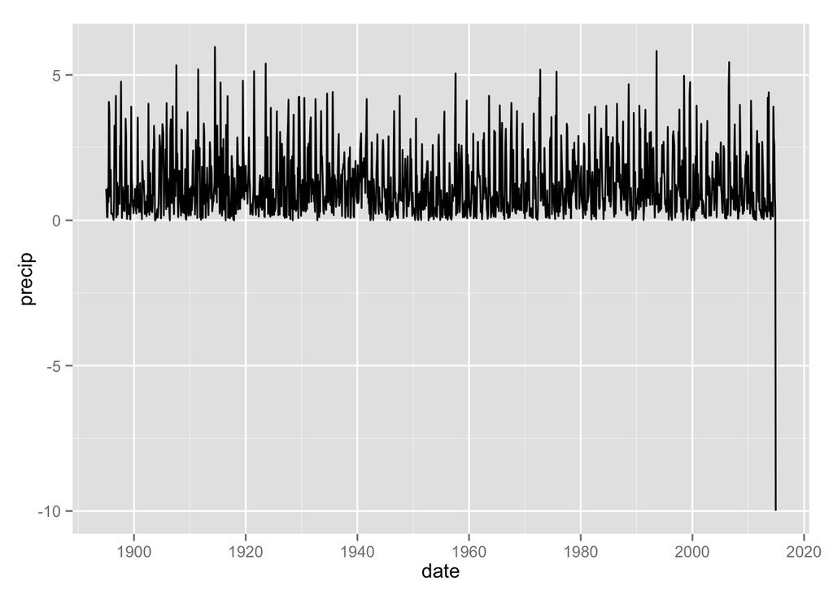

```r
# Plot:
ggplot(temp.data) + geom_line(aes(x=date, y=precip))
```